# Caballero Osorio, Fabian - Quiz 5 (Week 11) Feedback

| Course | Assessment |
| --- | --- |
| Machine Learning | Quiz 5 (Week 11) |

| Student Name | Student ID |
| --- | --- |
| Caballero Osorio, Fabian | S3912233 |

### Student Assessment Results & Feedback

Question

Student Answer

Correct Answer

Feedback

Score

Student Name & ID  
(link)  
(0 points)

Name: Fabian Mauricio Caballero Osorio  
Student ID: s3912233

Student Name & ID

*************************  
**STUDENT FEEDBACK:**  
*************************  
**(Student Name & ID)**

0.0

Question 1  
(link)  
(2 points)

Inability to process multinomial variables

Inability to process multinomial variables

*************************  
**STUDENT FEEDBACK:**  
*************************  
**Full credit was awarded for this answer.**  
*************************  
**GENERAL FEEDBACK:**  
*************************  
Please refer to the correct solutions.

2.0

Question 2  
(link)  
(2 points)

Decision trees handle missing values by imputing with mean value

Decision trees can handle both numerical and categorical features

*************************  
**STUDENT FEEDBACK:**  
*************************  
**No credit was awarded for this answer.**  
*************************  
**GENERAL FEEDBACK:**  
*************************  
Please refer to the correct solutions.

0.0

Question 3  
(link)  
(3 points)

```
import numpy as np

### ADD YOUR CODE BELOW

p = 1/6
face = 6
one = p*np.log2(p)


entropy = one*face

### ADD YOUR CODE ABOVE

print(f"entropy is {entropy:.2f} bits")

OUTPUT:
entropy is -2.58 bits
```

```
import numpy as np

### ADD YOUR CODE BELOW

probs = [1/6] * 6

entropy = -1 * np.sum(np.log2(probs) * probs)

# entropy = 999

### ADD YOUR CODE ABOVE

print(f"entropy is {entropy:.2f} bits")

OUTPUT:
entropy is 2.58 bits
```

*************************  
**STUDENT FEEDBACK:**  
*************************  
**No credit was awarded for this answer.**  
*************************  
**GENERAL FEEDBACK:**  
*************************  
Please refer to the correct solutions.

0.0

Question 4  
(link)  
(2 points)

1 - P(M | F,W,T)

1 - P(M | F,W,T)

*************************  
**STUDENT FEEDBACK:**  
*************************  
**Full credit was awarded for this answer.**  
*************************  
**GENERAL FEEDBACK:**  
*************************  
Please refer to the correct solutions.

2.0

Question 5  
(link)  
(3 points)

```
import numpy as np

### ADD YOUR CODE BELOW
target = [0, 0, 0, 1, 1, 1, 1, 1, 2, 2]
zero,one,two = 0,0,0
for i in target:
    if i==0:
        zero += 1
    if i==1:
        one += 1
    if i==2:
        two +=1
probs=[zero/len(target),one/len(target),two/len(target)]


gini = 1 - np.sum(np.square(probs))

### ADD YOUR CODE ABOVE

print(f"gini index is {gini:.2f}")

OUTPUT:
gini index is 0.62
```

```
### ADD YOUR CODE BELOW

probs = [3/10, 5/10, 2/10]

gini = 1 - np.sum(np.square(probs))

# gini = 999

### ADD YOUR CODE ABOVE

print(f"gini index is {gini:.2f}")

OUTPUT:
gini index is 0.62
```

*************************  
**STUDENT FEEDBACK:**  
*************************  
**Full credit was awarded for this answer.**  
*************************  
**GENERAL FEEDBACK:**  
*************************  
Please refer to the correct solutions.

3.0

Question 6  
(link)  
(3 points)

```
### ADD YOUR CODE BELOW

rate = 0.9
error = 0.10
P_incorrect = 3*(pow(0.10,2))*(pow(0.90,1))+1*(pow(0.10,3))*(pow(0.90,0))

accuracy = 1- P_incorrect

### ADD YOUR CODE ABOVE

print(f"accuracy rate of the ensemble model is {accuracy:.2f}")

OUTPUT:
accuracy rate of the ensemble model is 0.97
```

```
### ADD YOUR CODE BELOW

# From Slide #54 in Chapter 4 presentation:

# A: accurate, N: inaccurate
# Pr(correct prediction) = Pr(AAN) + Pr(NAA) + Pr(ANA) + Pr(AAA)

accuracy = 3*0.1*0.9*0.9 + 0.9**3

# accuracy = 999

### ADD YOUR CODE ABOVE

print(f"accuracy rate of the ensemble model is {accuracy:.2f}")

OUTPUT:
accuracy rate of the ensemble model is 0.97
```

*************************  
**STUDENT FEEDBACK:**  
*************************  
**Full credit was awarded for this answer.**  
*************************  
**GENERAL FEEDBACK:**  
*************************  
Please refer to the correct solutions.

3.0

Question 7  
(link)  
(2 points)

To improve the model's numerical stability

To improve the model's numerical stability

*************************  
**STUDENT FEEDBACK:**  
*************************  
**Full credit was awarded for this answer.**  
*************************  
**GENERAL FEEDBACK:**  
*************************  
Please refer to the correct solutions.

2.0

Question 8  
(link)  
(2 points)

0.35

0.35

*************************  
**STUDENT FEEDBACK:**  
*************************  
**Full credit was awarded for this answer.**  
*************************  
**GENERAL FEEDBACK:**  
*************************  
Since P(0|X) + P(1|X) = 1, the answer is 1 - 0.65 = 0.35.

2.0

Question 9  
(link)  
(2 points)

0.4

0.4

*************************  
**STUDENT FEEDBACK:**  
*************************  
**Full credit was awarded for this answer.**  
*************************  
**GENERAL FEEDBACK:**  
*************************  
P(X=1|Y=1) is the conditional probability of X=1 given that Y=1. It is calculated as the proportion of Y=1 instances where X=1. In this case, X=1 and Y=1 co-occur in 20 out of the 50 examples where Y=1, so P(X=1|Y=1) is 20/50 = 0.4.

2.0

Question 10  
(link)  
(2 points)

Decrease bias and increase variance

Decrease bias and increase variance

*************************  
**STUDENT FEEDBACK:**  
*************************  
**Full credit was awarded for this answer.**  
*************************  
**GENERAL FEEDBACK:**  
*************************  
The 'min_samples_split' parameter determines the minimum number of samples required to split an internal node. When we decrease this number, the decision tree can create more branches and thus may fit more closely to the training data. This will decrease bias, as the model can capture more complex patterns, but at the same time, it might increase variance, as the model may overfit the training data and perform poorly on unseen data. So, the correct answer is Decrease bias and increase variance.

2.0

Question 11  
(link)  
(4 points)

```
import numpy as np


num_yes = int(float(input('Waiting for input: ')))  # Example: 70
num_no  = int(float(input('Waiting for input: ')))  # Example: 30


def calculate_entropy(num_yes, num_no):

    ### ADD YOUR CODE BELOW
    total = num_yes + num_no
    p_yes = num_yes/total
    p_no = num_no/total
    e_yes = p_yes*np.log2(p_yes)
    e_no = p_no*np.log2(p_no)
    entropy =-1*(e_yes+e_no)

    ### ADD YOUR CODE ABOVE

    return entropy


# Calculate the entropy for the given problem
entropy = calculate_entropy(num_yes, num_no)

print(f'Entropy of the target variable is {entropy:.2f}')

UNIT TEST RESULTS:
Test 1: Passed! (Successful Test Output: Entropy of the target variable is 0.88)
```

```
import numpy as np


num_yes = int(float(input('Waiting for input: ')))  # Example: 70
num_no  = int(float(input('Waiting for input: ')))  # Example: 30


def calculate_entropy(num_yes, num_no):

    # Calculate the total number of instances
    total_instances = num_yes + num_no

    # Calculate the probability of 'Yes' and 'No'
    p_yes = num_yes / total_instances
    p_no = num_no / total_instances

    # Calculate the entropy
    entropy = -p_yes*np.log2(p_yes) - p_no*np.log2(p_no)

#     entropy = 999

    return entropy


# Calculate the entropy for the given problem
entropy = calculate_entropy(num_yes, num_no)

print(f'Entropy of the target variable is {entropy:.3f}')
```

*************************  
**STUDENT FEEDBACK:**  
*************************  
**Full credit was awarded for this answer.**  
*************************  
**GENERAL FEEDBACK:**  
*************************  
Please refer to the correct solutions.

4.0

Question 12  
(link)  
(3 points)

```
### ADD YOUR CODE BELOW

# Calculate the prior probabilities

# Calculate the likelihoods

# Calculate the posterior probabilities

# Normalize the probabilities


p_yes_given_sunny_mild_high = 999
p_no_given_sunny_mild_high = 999

### ADD YOUR CODE ABOVE


print(f"P(Yes | Sunny, Mild, High) = {p_yes_given_sunny_mild_high:.2f} and \
P(No | Sunny, Mild, High) = {p_no_given_sunny_mild_high:.2f}")

OUTPUT:
(Empty cell output encountered)
```

```
### ADD YOUR CODE BELOW

# Calculate the prior probabilities
total_instances = len(df)
yes_instances = len(df[df['Play Tennis'] == 'Yes'])
no_instances = len(df[df['Play Tennis'] == 'No'])

p_yes = yes_instances / total_instances
p_no = no_instances / total_instances

# Calculate the likelihoods
p_sunny_given_yes = len(df[(df['Outlook'] == 'Sunny') & (df['Play Tennis'] == 'Yes')]) / yes_instances
p_sunny_given_no = len(df[(df['Outlook'] == 'Sunny') & (df['Play Tennis'] == 'No')]) / no_instances

p_mild_given_yes = len(df[(df['Temperature'] == 'Mild') & (df['Play Tennis'] == 'Yes')]) / yes_instances
p_mild_given_no = len(df[(df['Temperature'] == 'Mild') & (df['Play Tennis'] == 'No')]) / no_instances

p_high_given_yes = len(df[(df['Humidity'] == 'High') & (df['Play Tennis'] == 'Yes')]) / yes_instances
p_high_given_no = len(df[(df['Humidity'] == 'High') & (df['Play Tennis'] == 'No')]) / no_instances

# Calculate the posterior probabilities
p_yes_given_sunny_mild_high = p_yes * p_sunny_given_yes * p_mild_given_yes * p_high_given_yes
p_no_given_sunny_mild_high = p_no * p_sunny_given_no * p_mild_given_no * p_high_given_no

# Normalize the probabilities
total = p_yes_given_sunny_mild_high + p_no_given_sunny_mild_high

p_yes_given_sunny_mild_high /= total
p_no_given_sunny_mild_high /= total

# p_yes_given_sunny_mild_high = 999
# p_no_given_sunny_mild_high = 999

### ADD YOUR CODE ABOVE

print(f"P(Yes | Sunny, Mild, High) = {p_yes_given_sunny_mild_high:.2f} and P(No | Sunny, Mild, High) = {p_no_given_sunny_mild_high:.2f}")

OUTPUT:
P(Yes | Sunny, Mild, High) = 0.24 and P(No | Sunny, Mild, High) = 0.76
```

*************************  
**STUDENT FEEDBACK:**  
*************************  
**No credit was awarded for this answer.**  
*************************  
**GENERAL FEEDBACK:**  
*************************  
Please refer to the correct solutions.

0.0

TOTAL: 22.0/30

### Assessment Unit Tests

| Question | Test Name | Test Input | Required Test Output |
| --- | --- | --- | --- |
| Question 11 | Test 1 | 70;30 | entropy of the target variable is 0.88 |

### Assessment Scores Histogram

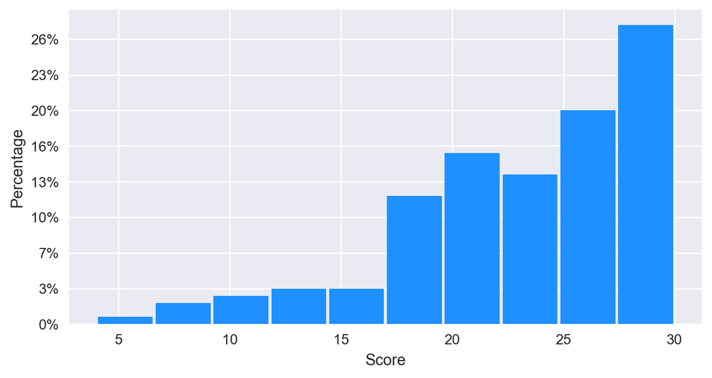

## Assessment Questions

**CODE OF CONDUCT**

- **Use of ChatGPT or similar AI tools is STRICTLY FORBIDDEN in our bi-weekly quizzes.**
- This is a "**limited open-computer**" assessment.
- **You must work on this assessment on your own and you must neither provide nor receive any help from anyone.**
- **You must not share this questions notebook nor your solutions with anyone, neither before submission nor after.**
- Please see Canvas for the full `Code of Conduct`.

**INSTRUCTIONS**

1. You **must not** delete any existing cells in this notebook and you **must not** modify any existing cell tags. If you accidentally delete a cell, you will need to go to the "Edit" menu option and select "Undo Delete Cells".
2. In an answer cell, any direct action **required from you** will be indicated by UPPER CASE PYTHON COMMENTS starting with "###".
3. In general, the value of "999" will denote a dummy placeholder.
4. You **must not change even a single character** in an existing code cell that is **outside** of the "ADD YOUR CODE BELOW/ ABOVE" block.
5. You **must not** have any additional print() statement outputs of your own for any question in your submission.
6. You **must** run each and every one of your answer cells so that your answers are recorded correctly for marking purposes.
7. Please keep in mind that, if you select "*Restart & Clear Output*" or "*Restart & Run All*" from the "*Kernel*" menu option, your answers for any multiple-choice questions will reset to "**nothing selected**".
8. Please see Canvas for additional assessment instructions.
9. This assessment has 12 questions for a total of 30 points.
10. Good luck!

```python
###
### PLEASE RUN THIS CELL SO THAT THE DROPDOWN ANSWER SELECTIONS BELOW WORK CORRECTLY
###
### WARNING!! If you restart your kernel, you will need to run this cell again.
###

import warnings
warnings.filterwarnings("ignore")

from ipywidgets import interactive
def function_mcq(selection): pass
```

```python
###
### PLEASE FIRST WRITE YOUR FULL NAME AND STUDENT ID BELOW,
### AND THEN EXECUTE THIS CODE CELL.
###

print("""
Name:
Student ID:
""")
```

## Question 1 (2 points)

Which of the following is NOT a common challenge faced when using decision trees?

```python
### PLEASE RUN THIS CELL

selection = [
'nothing selected',
'Prone to overfitting ',
'Unstable to small variations in the data ',
'Unable to easily capture linear relationships ',
'Inability to process multinomial variables ',
]

q1 = interactive(function_mcq, selection=selection);

display(q1)
```

```python
### PLEASE RUN THIS CELL AFTER YOUR SELECTION ABOVE
###
print(f"{q1.kwargs['selection']}")
```

**Go to Top**

## Question 2 (2 points)

Which of the following statements is TRUE about decision trees in general?

```python
### PLEASE RUN THIS CELL

selection = [
'nothing selected',
'Decision trees require feature scaling before implementation ',
'Decision trees can only handle classification tasks ',
'Decision trees handle missing values by imputing with mean value ',
'Decision trees can handle both numerical and categorical features ',
]

q2 = interactive(function_mcq, selection=selection);

display(q2)
```

```python
### PLEASE RUN THIS CELL AFTER YOUR SELECTION ABOVE
###
print(f"{q2.kwargs['selection']}")
```

**Go to Top**

## Question 3 (3 points)

What is the entropy of rolling a fair six-sided die? Note that each side has an equal probability of 1/6.

```python
import numpy as np

### ADD YOUR CODE BELOW


entropy = 999

### ADD YOUR CODE ABOVE

print(f"entropy is {entropy:.2f} bits")
```

**Go to Top**

## Question 4 (2 points)

For events F, W, T, and M in a naive Bayes classification setting, what is P(~M | F,W,T) where ~ is the negation operation? Below, P(A|B) denotes probability of event A conditioned on event B.

```python
### PLEASE RUN THIS CELL
###

selection = [
'nothing selected',
'1 - P(F,W,T | M) ',
'1 - (P(F|M) P(W|M) P(T|M) * P(M)) ',
'1 - P(M | F,W,T) ',
'None of the available choices '
]

q4 = interactive(function_mcq,
                 selection=selection);

display(q4)
```

```python
### PLEASE RUN THIS CELL AFTER YOUR SELECTION ABOVE
###
print(f"{q4.kwargs['selection']}")
```

**Go to Top**

## Question 5 (3 points)

Below are the 10 actual values of a target variable:

[0, 0, 0, 1, 1, 1, 1, 1, 2, 2]

What is the gini impurity index of this variable?

```python
import numpy as np

### ADD YOUR CODE BELOW


gini = 999

### ADD YOUR CODE ABOVE

print(f"gini index is {gini:.2f}")
```

**Go to Top**

## Question 6 (3 points)

Consider an ensemble of three different models for a binary classification problem. All three models are assumed to be independent with the same accuracy rate of 0.9. This ensemble uses a simple majority vote for producing a final prediction. Compute the accuracy rate of this ensemble model.

```python
### ADD YOUR CODE BELOW


accuracy = 999

### ADD YOUR CODE ABOVE

print(f"accuracy rate of the ensemble model is {accuracy:.2f}")
```

**Go to Top**

## Question 7 (2 points)

Why might we apply variance smoothing in a Naive Bayes classifier?

```python
### PLEASE RUN THIS CELL
###

selection = [
'nothing selected',
'To reduce the complexity of the model ',
"To improve the model's numerical stability ",
'To increase the training speed of the model ',
"To improve the model's accuracy on the training set "
]

q7 = interactive(function_mcq, selection=selection);

display(q7)
```

```python
### PLEASE RUN THIS CELL AFTER YOUR SELECTION ABOVE
###
print(f"{q7.kwargs['selection']}")
```

**Go to Top**

## Question 8 (2 points)

Given a binary classification problem with classes 0 and 1, if the Naive Bayes classifier calculates P(1|X) = 0.65, what is P(0|X)?

```python
### PLEASE RUN THIS CELL
###

selection = [
'nothing selected',
'0.45',
'0.35',
'0.55',
'0.65',
'None of the above'
]

q8 = interactive(function_mcq, selection=selection);

display(q8)
```

```python
### PLEASE RUN THIS CELL AFTER YOUR SELECTION ABOVE
###
print(f"{q8.kwargs['selection']}")
```

**Go to Top**

## Question 9 (2 points)

In Naive Bayes, suppose we have a binary feature X (taking values 0 or 1) and binary output Y (taking values 0 or 1). In the training set of 100 examples, X=1 and Y=1 co-occur in 20 examples. If we know that Y=1 in 50 out of the 100 examples, what is P(X=1|Y=1)?

```python
### PLEASE RUN THIS CELL
###

selection = [
'nothing selected',
'0.2',
'0.4',
'0.5',
'0.6',
'None of the above'
]

q9 = interactive(function_mcq, selection=selection);

display(q9)
```

```python
### PLEASE RUN THIS CELL AFTER YOUR SELECTION ABOVE
###
print(f"{q9.kwargs['selection']}")
```

**Go to Top**

## Question 10 (2 points)

In the context of decision trees in Scikit-Learn, how would a decrease in the parameter `min_samples_split` from 50 to 10 most likely affect the model's performance?

```python
### PLEASE RUN THIS CELL
###

selection = [
'nothing selected',
'Increase bias and decrease variance ',
'Decrease bias and increase variance ',
'Both bias and variance would increase ',
'Both bias and variance would decrease '
]

q10 = interactive(function_mcq, selection=selection);

display(q10)
```

```python
### PLEASE RUN THIS CELL AFTER YOUR SELECTION ABOVE
###
print(f"{q10.kwargs['selection']}")
```

**Go to Top**

## Question 11 (4 points)

Consider a binary classification problem where the target variable can take two values: 'Yes' and 'No'. Specifically, in your dataset, some instances are labeled as 'Yes' and the other instances are labeled as 'No'.

Write a Python function, `calculate_entropy()`, to calculate the entropy of the target variable. The function should take two arguments: the number of 'Yes' instances and the number of 'No' instances, and it should return the calculated entropy.

```python
import numpy as np


num_yes = int(float(input('Waiting for input: ')))  # Example: 70
num_no  = int(float(input('Waiting for input: ')))  # Example: 30


def calculate_entropy(num_yes, num_no):

    ### ADD YOUR CODE BELOW


    entropy = 999

    ### ADD YOUR CODE ABOVE

    return entropy


# Calculate the entropy for the given problem
entropy = calculate_entropy(num_yes, num_no)

print(f'Entropy of the target variable is {entropy:.2f}')
```

**Go to Top**

## Question 12: Challenge Question (3 points)

**This is a Challenge Question, please only attempt this AFTER attempting the rest of the questions!**

**Also be aware of how much time you have left!**

In this question, you will use the naive Bayes classifier to make a binary prediction for a particular dataset. Specifically, given tomorrow's weather outlook, temperature, and humidity, you will predict if a tennis court will be used or not (Play Tennis is `Yes` or `No`). This dataset is given below as a Pandas dataframe.

You will provide your prediction for the following instance:

- Outlook = Sunny
- Temperature = Mild
- Humidity = High

You will manually compute the following two conditional probabilities as your answer for this question (**without** using Scikit-learn):

- Pr(Yes | Sunny, Mild, High)
- Pr(No | Sunny, Mild, High)

Please note that the higher of the above two will obviously be the final prediction.

**Clarification:** Please do **not** perform any train-test splitting or one-hot-encoding for this question.

```python
import pandas as pd

# Create a DataFrame
data = {
    'Outlook': ['Sunny', 'Sunny', 'Overcast', 'Rainy', 'Rainy', 'Rainy', 'Overcast', 'Sunny', 'Sunny', 'Rainy', 'Sunny', 'Overcast', 'Overcast', 'Rainy'],
    'Temperature': ['Hot', 'Hot', 'Hot', 'Mild', 'Cool', 'Cool', 'Cool', 'Mild', 'Cool', 'Mild', 'Mild', 'Mild', 'Hot', 'Mild'],
    'Humidity': ['High', 'High', 'High', 'High', 'Normal', 'Normal', 'Normal', 'High', 'Normal', 'Normal', 'Normal', 'High', 'Normal', 'High'],
    'Play Tennis': ['No', 'No', 'Yes', 'Yes', 'Yes', 'No', 'Yes', 'No', 'Yes', 'Yes', 'Yes', 'Yes', 'Yes', 'No']
}
df = pd.DataFrame(data)

df
```

|  | Outlook | Temperature | Humidity | Play Tennis |
| --- | --- | --- | --- | --- |
| 0 | Sunny | Hot | High | No |
| 1 | Sunny | Hot | High | No |
| 2 | Overcast | Hot | High | Yes |
| 3 | Rainy | Mild | High | Yes |
| 4 | Rainy | Cool | Normal | Yes |
| 5 | Rainy | Cool | Normal | No |
| 6 | Overcast | Cool | Normal | Yes |
| 7 | Sunny | Mild | High | No |
| 8 | Sunny | Cool | Normal | Yes |
| 9 | Rainy | Mild | Normal | Yes |
| 10 | Sunny | Mild | Normal | Yes |
| 11 | Overcast | Mild | High | Yes |
| 12 | Overcast | Hot | Normal | Yes |
| 13 | Rainy | Mild | High | No |

```python
### ADD YOUR CODE BELOW

# Calculate the prior probabilities

# Calculate the likelihoods

# Calculate the posterior probabilities

# Normalize the probabilities


p_yes_given_sunny_mild_high = 999
p_no_given_sunny_mild_high = 999

### ADD YOUR CODE ABOVE


print(f"P(Yes | Sunny, Mild, High) = {p_yes_given_sunny_mild_high:.2f} and \
P(No | Sunny, Mild, High) = {p_no_given_sunny_mild_high:.2f}")
```

**Go to Top**

Marking & Feedback by **[SageGrader.com](https://sagegrader.com)**: The Sage Way To Grade.